# exploratoryDataAnalysis

# Load libraries

```r
library(tidyverse)
library(dplyr)
library(patchwork)
library(car)
```

# Load data

```r
data <- read.csv("data/AmesHousing.csv", header = TRUE, sep = ";")
```

# EDA

```r
source("src/edaFunctions.R")
```

## Select chosen variables

For this analysis, we are using the Ames Housing dataset to model residential property sales. We have selected a subset of variables that capture size, quality, age, and location characteristics.

Target Variable SalePrice: The property’s sale price in US dollars. This is the response variable we aim to predict.

Explanatory Variables Size & Space

GrLivArea: Above grade (ground) living area square footage.

TotalBsmtSF: Total square footage of the basement area.

GarageArea: Size of the garage in square feet.

LotArea: Lot size in square feet.

Condition & Age

OverallQual: Rates the overall material and finish of the house (1 = Very Poor, 10 = Very Excellent).

YearBuilt: Original construction date.

YearRemodAdd: Remodel date (same as construction date if no remodeling or additions).

Location & Style

Neighborhood: Physical locations within Ames city limits. In the US market, this is a strong proxy for school districts, distance to the university, and neighborhood prestige, which drastically affects value independent of the house itself.

HouseStyle: Describes the vertical layout of the house. Common types include:

- 1-Story: “Ranch” style (all ground level).
- 2-Story: Bedrooms typically upstairs.
- 1.5-Story: Older homes with converted attics (slanted ceilings).
- Split-Level: Staggered floors with short flights of stairs.

store them

```r
explanatoryVars <- c("Gr.Liv.Area", "Total.Bsmt.SF", "Garage.Area", "Lot.Area",
                      "Overall.Qual", "Year.Built", "Year.Remod.Add",
                      "Neighborhood", "House.Style")

targetVar <- c("SalePrice")

idVars <-  c("Order","PID")
```

```r
df <- data[, explanatoryVars]

target <- data[targetVar]
```

## Missing values

```r
missingValues <- colSums(is.na(df))
as.data.frame(missingValues)
```

```
##                missingValues
## Gr.Liv.Area                0
## Total.Bsmt.SF              1
## Garage.Area                1
## Lot.Area                   0
## Overall.Qual               0
## Year.Built                 0
## Year.Remod.Add             0
## Neighborhood               0
## House.Style                0
```

```r
missingValuesTarget <- colSums(is.na(target))
as.data.frame(missingValuesTarget)
```

```
##           missingValuesTarget
## SalePrice                   0
```

## STUDY numerical variables

Explanatory variables

```r
numDescription <- numerical_descriptive(df)
numDescription
```

```
##    statistic Gr.Liv.Area Total.Bsmt.SF Garage.Area   Lot.Area Overall.Qual
## 1      n_obs    2930.000      2929.000    2929.000   2930.000     2930.000
## 2     n_miss       0.000         1.000       1.000      0.000        0.000
## 3       mean    1499.690      1051.615     472.820  10147.922        6.095
## 4         sd     505.509       440.615     215.047   7880.018        1.411
## 5        min     334.000         0.000       0.000   1300.000        1.000
## 6        q25    1126.000       793.000     320.000   7440.250        5.000
## 7     median    1442.000       990.000     480.000   9436.500        6.000
## 8        q75    1742.750      1302.000     576.000  11555.250        7.000
## 9        max    5642.000      6110.000    1488.000 215245.000       10.000
## 10  skewness       1.273         1.156       0.242     12.814        0.191
## 11  kurtosis       7.129        12.118       3.947    267.570        3.050
##    Year.Built Year.Remod.Add
## 1    2930.000       2930.000
## 2       0.000          0.000
## 3    1971.356       1984.267
## 4      30.245         20.860
## 5    1872.000       1950.000
## 6    1954.000       1965.000
## 7    1973.000       1993.000
## 8    2001.000       2004.000
## 9    2010.000       2010.000
## 10     -0.604         -0.452
## 11      2.497          1.659
```

Target Variables

```r
numerical_descriptive(target)
```

```
##    statistic  SalePrice
## 1      n_obs   2930.000
## 2     n_miss      0.000
## 3       mean 180796.060
## 4         sd  79886.692
## 5        min  12789.000
## 6        q25 129500.000
## 7     median 160000.000
## 8        q75 213500.000
## 9        max 755000.000
## 10  skewness      1.743
## 11  kurtosis      8.108
```

## Study discrete variables

```r
categoricalDescription <- categorical_summary(df)
categoricalDescription
```

```
##      statistic Neighborhood House.Style
## 1        n_obs         2930        2930
## 2       n_miss            0           0
## 3     n_levels           28           8
## 4         mode        NAmes      1Story
## 5    mode_freq          443        1481
## 6 mode_percent        0.151       0.505
```

## Distributions and Histograms

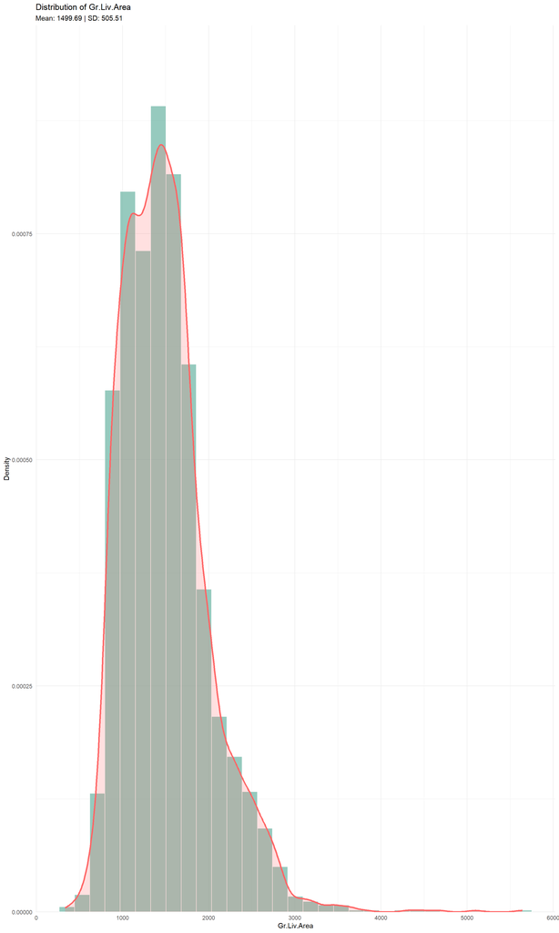

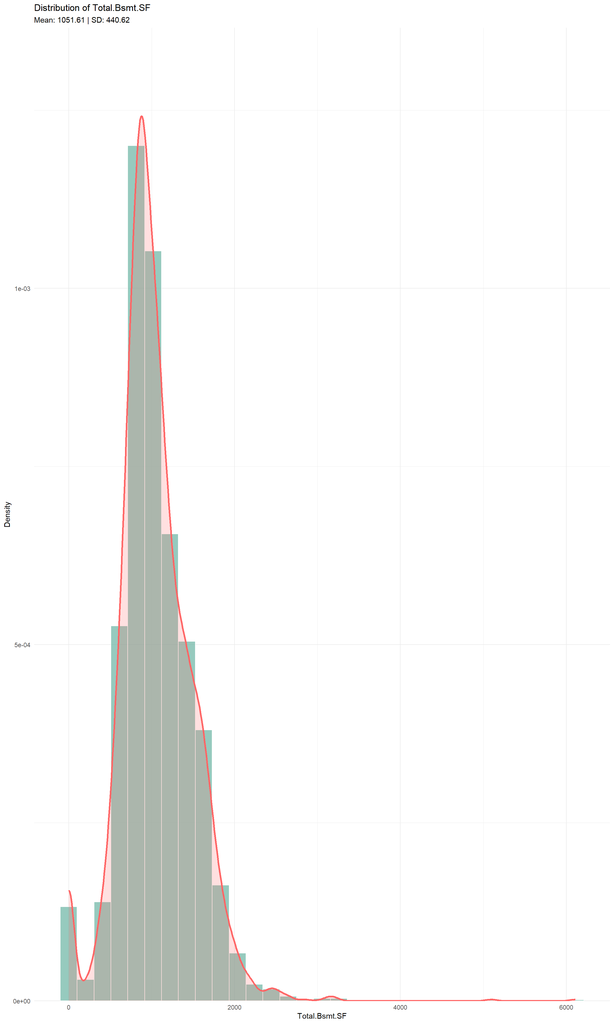

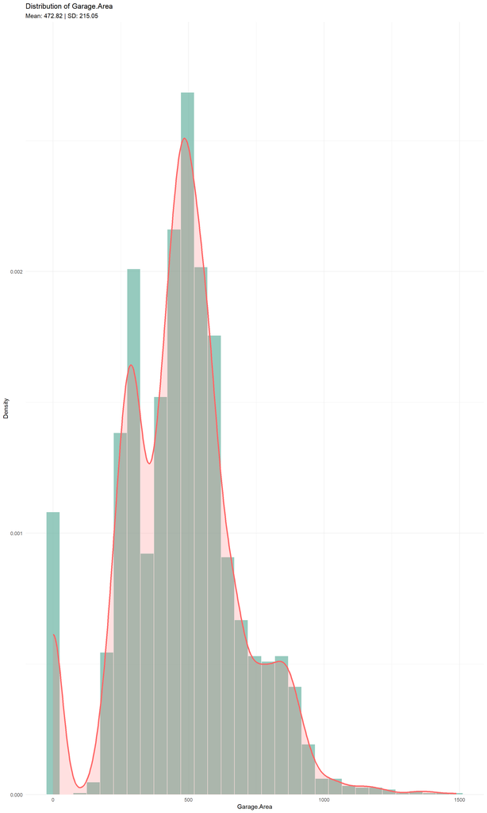

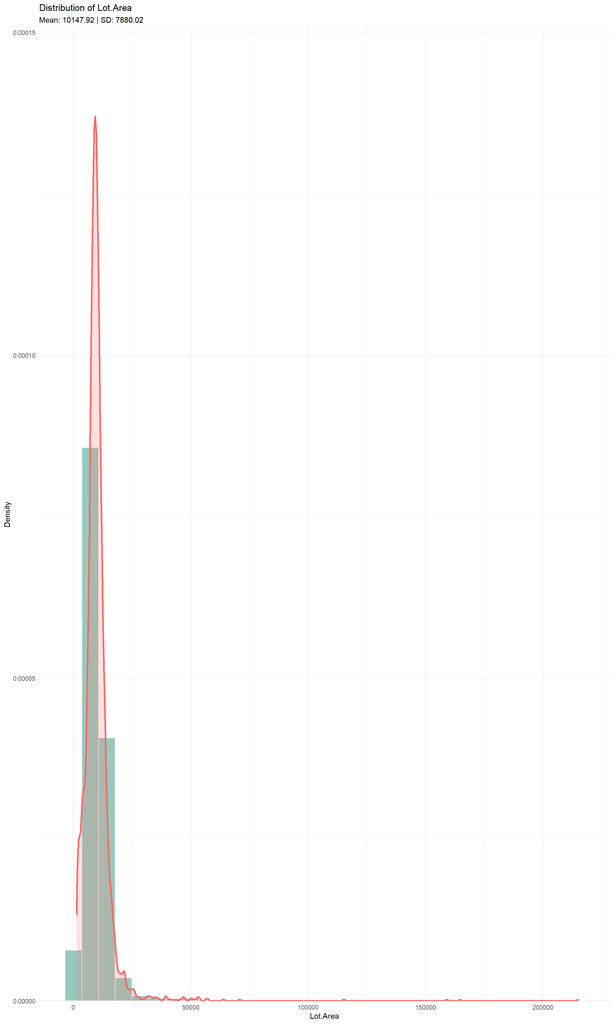

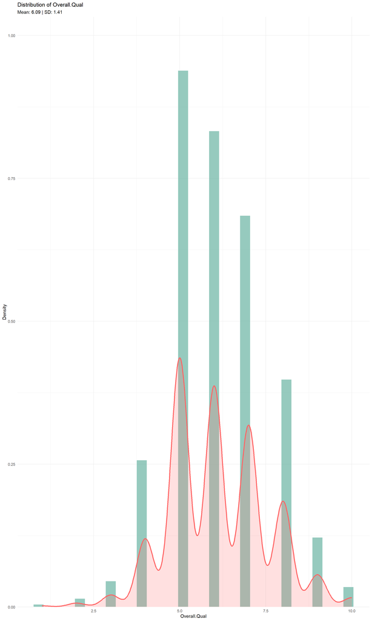

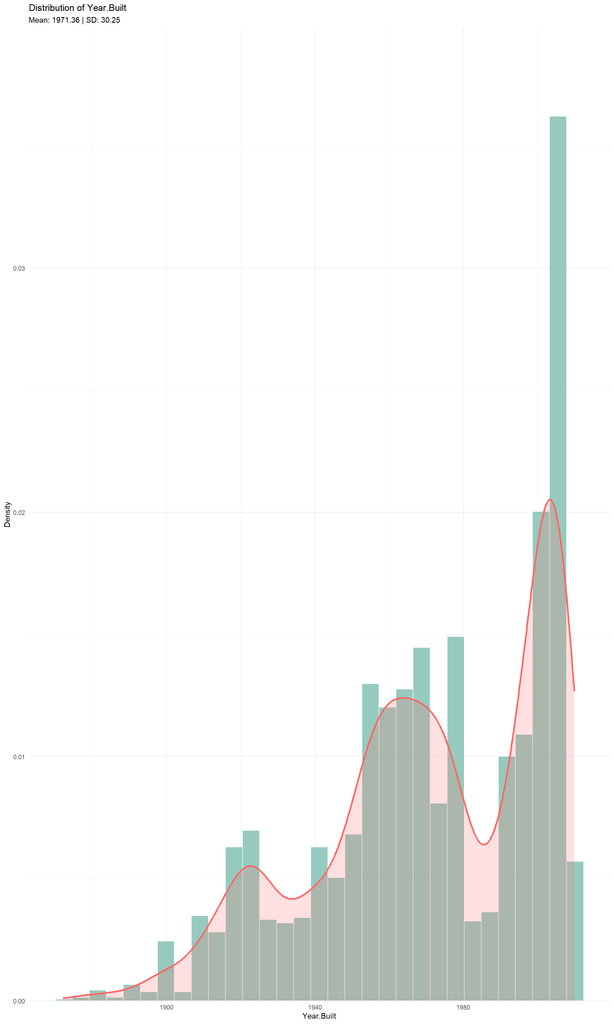

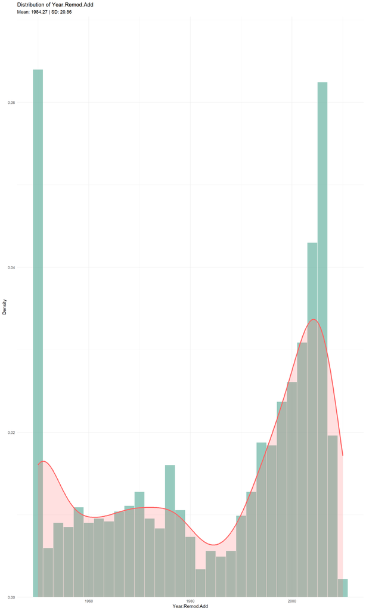

```r
for (name in explanatoryVars) {
  if (is.numeric(df[[name]])) {

    # To allow for dinamic binwidth based on variable range
    var_range <- max(df[[name]], na.rm = TRUE) - min(df[[name]], na.rm = TRUE)
    dynamic_binwidth <- var_range / 30

    # 2. Create the plot
    p <- ggplot(df, aes_string(x = name)) +


      geom_histogram(aes(y = ..density..),
                     binwidth = dynamic_binwidth,
                     fill = "#69b3a2",   # A nicer teal color
                     color = "white",    # White borders separate bars clearly
                     alpha = 0.7) +      # Slight transparency

      # DENSITY LINE
      geom_density(color = "#FF6666", size = 1.2, fill = "#FF6666", alpha = 0.2) +

      # labels
      labs(title = paste("Distribution of", name),
           subtitle = paste("Mean:", round(mean(df[[name]], na.rm=TRUE), 2),
                            "| SD:", round(sd(df[[name]], na.rm=TRUE), 2)),
           x = name,
           y = "Density") +

      theme_minimal() +


      scale_y_continuous(expand = expansion(mult = c(0, 0.1)))

    print(p)
    ggsave(filename = paste0("plots/distribution_", name, ".png"), plot = p, width = 8, height = 6)

  }
}
```

### Categorical variables Plot Neighborhood

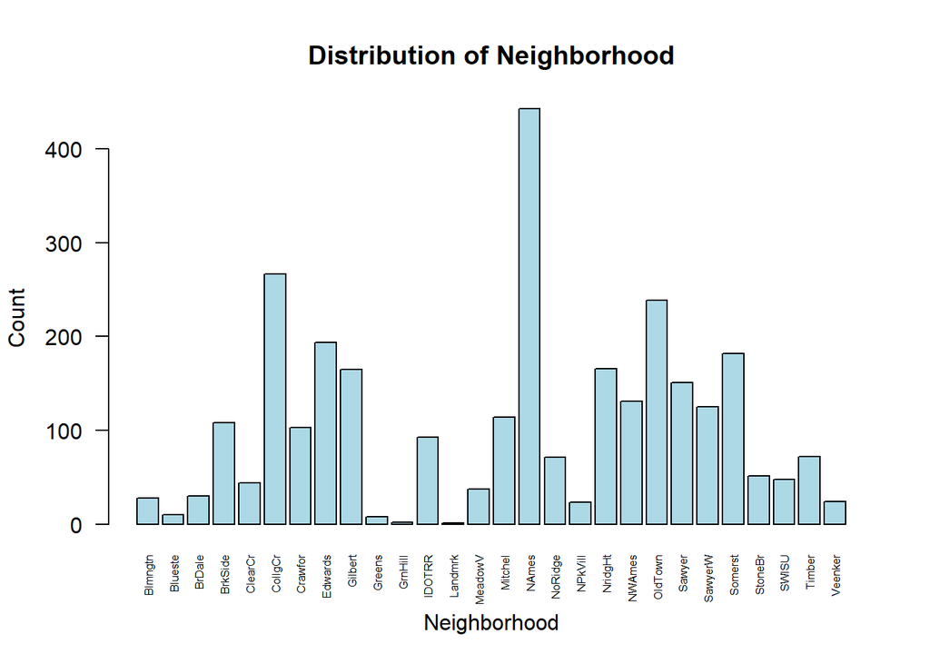

```r
barplot(table(df$Neighborhood), main="Distribution of Neighborhood",
        xlab="Neighborhood", ylab="Count", las=2, col="lightblue", cex.names=0.5)
```

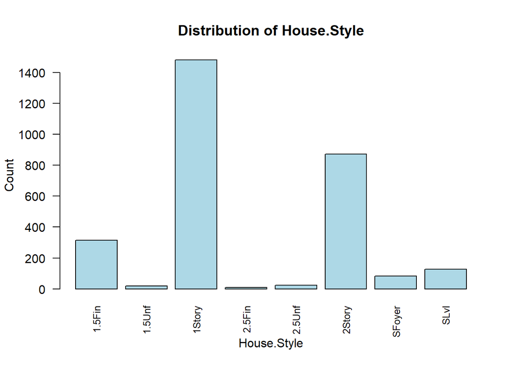

```r
barplot(table(df$House.Style), main="Distribution of House.Style",
        xlab="House.Style", ylab="Count", las=2, col="lightblue", cex.names=0.8)
```

## Check for lienarity

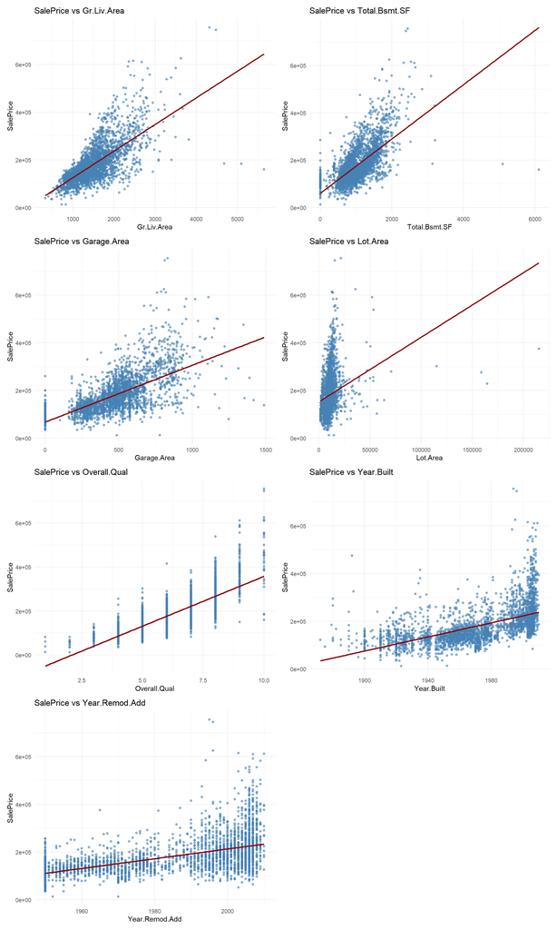

```r
df <- data[c(explanatoryVars, targetVar)]
wrap_plots(pairwiseplot_for_linearity(df, "SalePrice"), ncol = 2, nrow = 4)
```

### Linearity for categorical variables

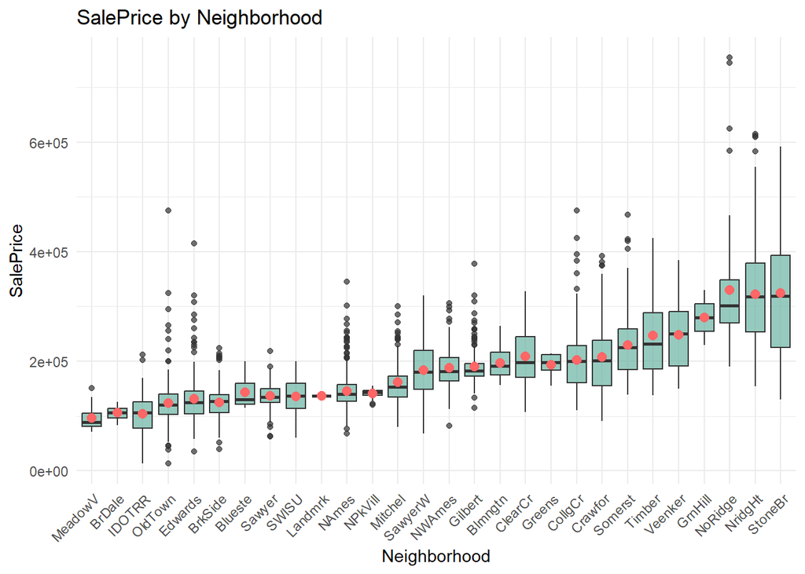

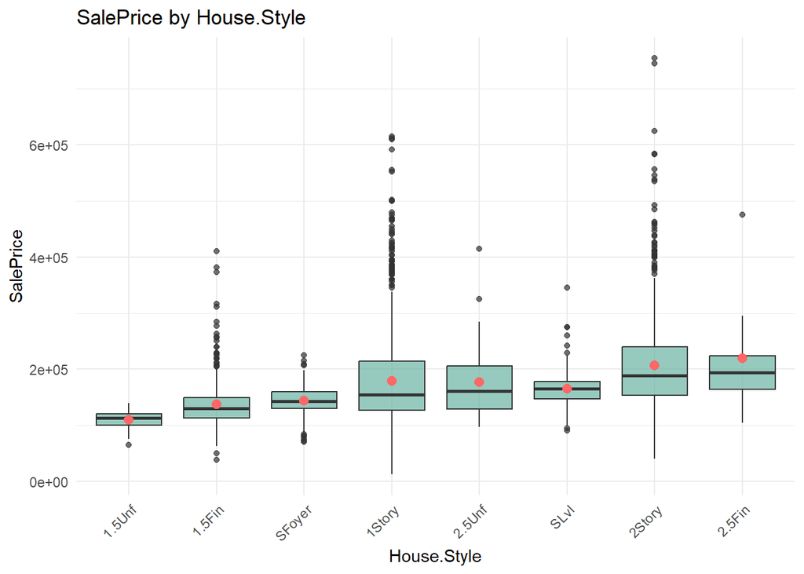

```r
for (catVar in c("Neighborhood", "House.Style")) {
  p <- ggplot(df, aes(x = reorder(.data[[catVar]], SalePrice, FUN = median),
                      y = SalePrice)) +
    geom_boxplot(fill = "#69b3a2", alpha = 0.7) +
    stat_summary(fun = mean, geom = "point", shape = 20, size = 4, color = "#FF6666", fill = "#FF6666") +
    labs(title = paste("SalePrice by", catVar),
         x = catVar,
         y = "SalePrice") +
    theme_minimal() +
    theme(axis.text.x = element_text(angle = 45, hjust = 1))

  print(p)
  ggsave(filename = paste0("plots/linearity_SalePrice_vs_", catVar, ".png"), plot = p, width = 8, height = 6)
}
```

## Correlation Matrix

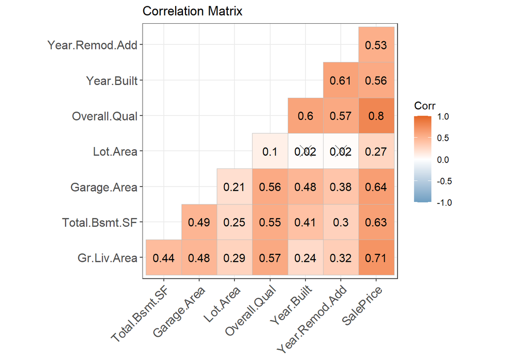

```r
plot_correlation_matrix(df)
```

```r
# save plot
ggsave(filename = "plots/correlation_matrix.png", width = 8, height = 6)
```